# CTABusData

## MIS 307 Final Project

This code defines a function `read_cta_data` that reads data from a CSV file located at the specified `file_path`. It reads the CSV file using the `csv.reader` module and returns the header (first row) and the rest of the data as a list of lists.

Then, it reads data from the file "CTA_Average_Bus_Ridership_1999_2023.csv" using this function, prints the header, and displays the first 5 rows of data.

This function is a flexible way to read CSV data and can be reused for other CSV files by passing different file paths as arguments.

```python
import csv

def read_cta_data(file_path):
    cta_data = []
    with open(file_path, 'r') as file:
        csv_reader = csv.reader(file)
        header = next(csv_reader)
        for row in csv_reader:
            cta_data.append(row)
    return header, cta_data

file_path = "CTA_Average_Bus_Ridership_1999_2023.csv"
header, cta_data = read_cta_data(file_path)

print("Header:", header)
print("First 5 rows of data:")
for row in cta_data[:5]:
    print(row)
```

```
Header: ['\ufeffROUTE', 'YEAR', 'MONTH', 'DAY_TYPE', 'AVG_RIDES']
First 5 rows of data:
['0', '2023', '10', 'Weekday', '2626']
['0', '2023', '10', 'Saturday', '4694']
['0', '2023', '10', 'Sunday - Holiday', '2634']
['1', '2023', '10', 'Weekday', '1126']
['100', '2023', '10', 'Weekday', '470']
```

This code snippet assumes that you have already read the CSV file into the `header` and `cta_data` variables. It then proceeds to create a DataFrame using pandas, converting the 'AVG_RIDES' and 'MONTH' columns to numeric data types. After printing the column names, it pivots the DataFrame to prepare the data for a heatmap visualization.

The heatmap is created using Seaborn, with 'YEAR' on the y-axis, 'MONTH' on the x-axis, and 'AVG_RIDES' as the values. The heatmap represents the sum of average ridership for each month and year from 1999 to 2023.

This visualization allows you to observe patterns and trends in CTA bus average ridership over the specified time period, with brighter colors indicating higher ridership values.

```
Index(['ROUTE', 'YEAR', 'MONTH', 'DAY_TYPE', 'AVG_RIDES'], dtype='object')
```

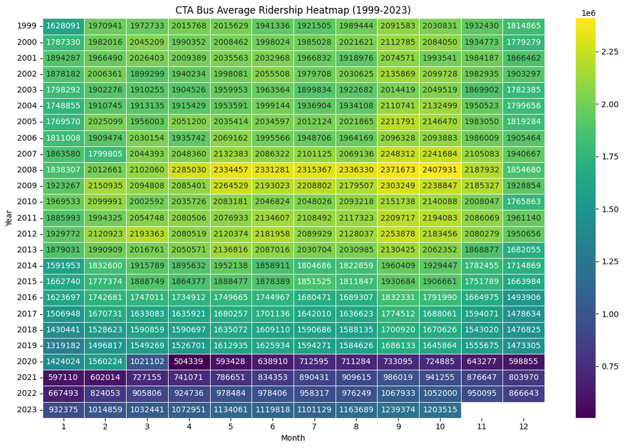

```python
import pandas as pd
import seaborn as sns
import matplotlib.pyplot as plt

# Assuming you have already read the CSV file into header and cta_data variables

# Create a DataFrame from the CSV data
df = pd.DataFrame(cta_data, columns=header)

# Convert 'AVG_RIDES' column to numeric
df['AVG_RIDES'] = pd.to_numeric(df['AVG_RIDES'])

# Convert 'MONTH' column to numeric
df['MONTH'] = pd.to_numeric(df['MONTH'])

# Print the column names
print(df.columns)

# Pivot the DataFrame to prepare for heatmap
heatmap_data = df.pivot_table(index='YEAR', columns='MONTH', values='AVG_RIDES', aggfunc='sum')

# Create the heatmap
plt.figure(figsize=(12, 8))
sns.heatmap(heatmap_data, cmap='viridis', annot=True, fmt=".0f", linewidths=.5)
plt.title('CTA Bus Average Ridership Heatmap (1999-2023)')
plt.xlabel('Month')
plt.ylabel('Year')
plt.tight_layout()
plt.show()
```

This code snippet assumes that you've already read the CSV file into the `header` and `cta_data` variables. It creates a DataFrame from the CSV data and prints the column names to verify the data.

Then, it converts the 'AVG_RIDES' column to numeric data type, handling errors with the 'coerce' option to replace invalid parsing with NaN values. Next, non-numeric columns ('ROUTE', 'YEAR', 'MONTH', 'DAY_TYPE') are dropped from the DataFrame.

Rows with missing values are then dropped from the DataFrame. Finally, all columns are converted to numeric data type using the `pd.to_numeric` function.

```
Index(['ROUTE', 'YEAR', 'MONTH', 'DAY_TYPE', 'AVG_RIDES'], dtype='object')
```

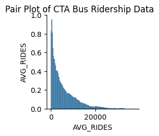

```python
import pandas as pd
import seaborn as sns
import matplotlib.pyplot as plt

# Assuming you have already read the CSV file into header and cta_data variables

# Create a DataFrame from the CSV data
df = pd.DataFrame(cta_data, columns=header)

# Print column names to verify
print(df.columns)

# Convert 'AVG_RIDES' column to numeric
df['AVG_RIDES'] = pd.to_numeric(df['AVG_RIDES'], errors='coerce')

# Drop non-numeric columns
non_numeric_columns = ['\ufeffROUTE', 'YEAR', 'MONTH', 'DAY_TYPE']
df_numeric = df.drop(non_numeric_columns, axis=1)

# Drop rows with missing values
df_numeric = df_numeric.dropna()

# Convert all columns to numeric
df_numeric = df_numeric.apply(pd.to_numeric)

# Create pair plot
sns.pairplot(df_numeric)
plt.suptitle('Pair Plot of CTA Bus Ridership Data', y=1.02)
plt.show()
```

This code snippet prints the column names and row index labels of the DataFrame df. It helps in understanding the structure and organization of the dataset, providing information about the column names and index labels.

```python
# Display column names
print("Column Names:")
print(df.columns)

# Display row names (index)
print("\nRow Names (Index):")
print(df.index)
```

```
Column Names:
Index(['ROUTE', 'YEAR', 'MONTH', 'DAY_TYPE', 'AVG_RIDES'], dtype='object')

Row Names (Index):
RangeIndex(start=0, stop=95996, step=1)
```

This code snippet assumes that you've already read the CSV file into the `header` and `cta_data` variables. It creates a DataFrame from the CSV data, converts the 'AVG_RIDES' column to numeric data type, and then combines the 'YEAR' and 'MONTH' columns to create a new 'DATE' column with datetime format.

The DataFrame is then grouped by month, and the average ridership for each month is calculated. Finally, a time series plot is created to visualize the average CTA bus ridership over time on a monthly basis.

The plot displays the trend in average ridership over the specified time period, allowing you to observe any seasonal patterns or trends in CTA bus ridership.

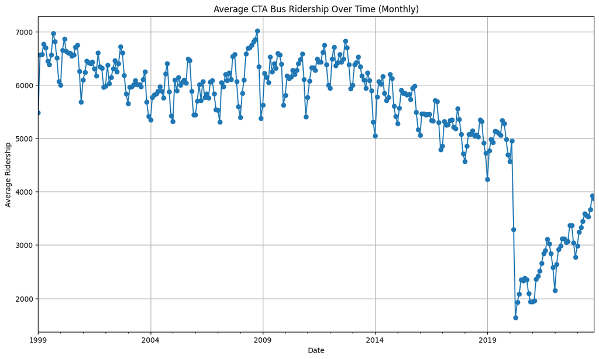

```python
import pandas as pd
import matplotlib.pyplot as plt

# Assuming you have already read the CSV file into header and cta_data variables

# Create a DataFrame from the CSV data
df = pd.DataFrame(cta_data, columns=header)

# Convert 'AVG_RIDES' column to numeric
df['AVG_RIDES'] = pd.to_numeric(df['AVG_RIDES'])

# Convert 'YEAR' and 'MONTH' columns to datetime
df['DATE'] = pd.to_datetime(df['YEAR'] + '-' + df['MONTH'], format='%Y-%m')

# Group by month and calculate the average ridership
average_ridership = df.groupby(pd.Grouper(key='DATE', freq='M'))['AVG_RIDES'].mean()

# Plot the time series
plt.figure(figsize=(14, 8))  # Larger figure size
average_ridership.plot(marker='o')  # Add markers for each data point
plt.title('Average CTA Bus Ridership Over Time (Monthly)')
plt.xlabel('Date')
plt.ylabel('Average Ridership')
plt.grid(True)
plt.show()
```

This code snippet assumes that you've already read the CSV file into the `header` and `cta_data` variables. It creates a DataFrame from the CSV data and converts the 'AVG_RIDES' column to numeric data type.

Then, it creates a histogram to visualize the distribution of CTA bus ridership. The histogram bins the average ridership values into 20 intervals and displays the frequency of ridership values within each interval.

This visualization helps in understanding the distribution of CTA bus ridership across different average ridership levels, providing insights into the typical ridership patterns and identifying any outliers or unusual trends.

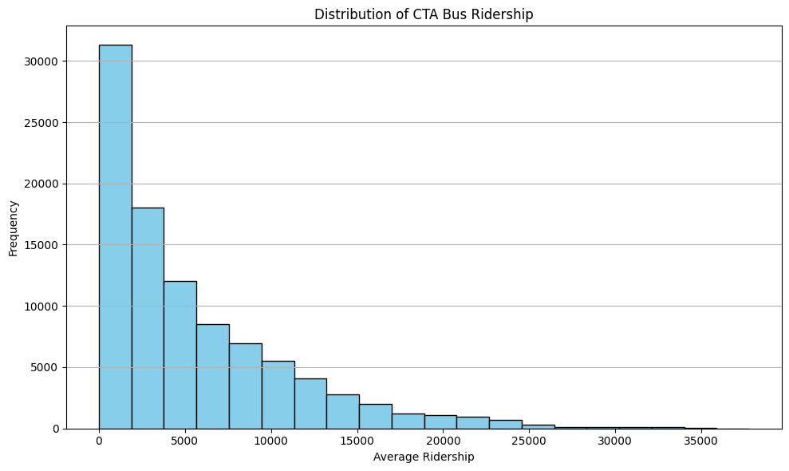

```
''
```

```python
import pandas as pd
import matplotlib.pyplot as plt

# Assuming you have already read the CSV file into header and cta_data variables

# Create a DataFrame from the CSV data
df = pd.DataFrame(cta_data, columns=header)

# Convert 'AVG_RIDES' column to numeric
df['AVG_RIDES'] = pd.to_numeric(df['AVG_RIDES'])

# Plot the histogram
plt.figure(figsize=(10, 6))
plt.hist(df['AVG_RIDES'], bins=20, color='skyblue', edgecolor='black')
plt.title('Distribution of CTA Bus Ridership')
plt.xlabel('Average Ridership')
plt.ylabel('Frequency')
plt.grid(axis='y')
plt.tight_layout()
plt.show()


''
```

This code snippet assumes that you've already read the CSV file into the `header` and `cta_data` variables. It creates a DataFrame from the CSV data using pandas' `DataFrame` constructor and prints the column names to verify the data.

Printing the column names is a useful step to ensure that the DataFrame has been constructed correctly and that the column names match the expected headers from the CSV file. This helps in understanding the structure and organization of the dataset before proceeding with further analysis or visualization.

```python
import pandas as pd

# Assuming you have already read the CSV file into header and cta_data variables

# Create a DataFrame from the CSV data
df = pd.DataFrame(cta_data, columns=header)

# Print column names to verify
print(df.columns)
```

```
Index(['ROUTE', 'YEAR', 'MONTH', 'DAY_TYPE', 'AVG_RIDES'], dtype='object')
```

This code reads the CSV file "CTA_Average_Bus_Ridership_1999_2023.csv" into a DataFrame using pandas and performs predictive modeling to estimate average bus ridership.

First, it extracts additional features by creating a 'DATE' column from the 'YEAR' and 'MONTH' columns. Then, it prepares the features (X) and target variable (y), splitting the data into training and testing sets.

A Random Forest Regressor model with 100 estimators is trained using the training data. Cross-validation is performed for model evaluation, and the mean root mean squared error (RMSE) is calculated.

Predictions are made on the testing set, and the model is evaluated using mean squared error and R-squared. Actual vs. predicted values are visualized using a scatter plot.

This approach provides insights into potential future bus ridership trends based on historical data and demonstrates the performance of the Random Forest Regressor model in predicting average bus ridership.

```
Cross-Validation RMSE Scores:
0    5439.720697
1    5425.170553
2    5411.207528
3    5497.438790
4    5353.323398
dtype: float64
Mean RMSE: 5425.372193048493

Test Set Metrics:
Mean Squared Error: 29738655.53869723
R-squared: 0.0414904830850793
```

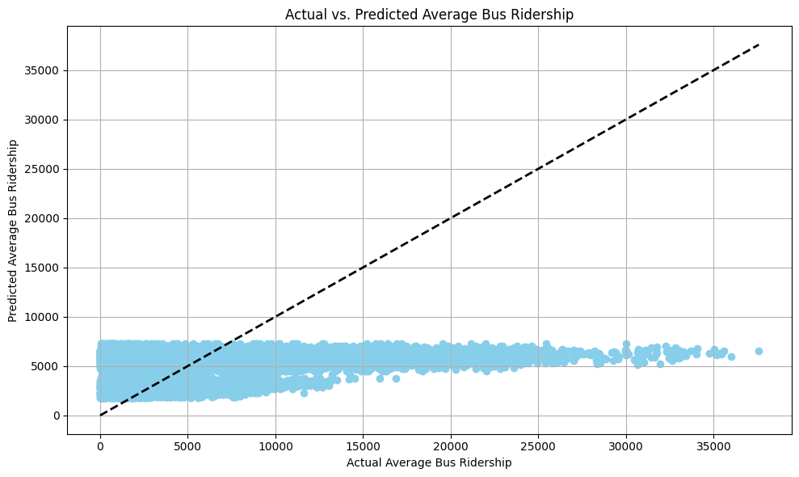

```
Predicted Average Bus Ridership for the Next Month: 3412.713225749476
```

```python
import pandas as pd
from sklearn.model_selection import train_test_split, cross_val_score
from sklearn.ensemble import RandomForestRegressor
from sklearn.metrics import mean_squared_error, r2_score
import matplotlib.pyplot as plt

# Read the CSV file into a DataFrame
bus_ridership_df = pd.read_csv("CTA_Average_Bus_Ridership_1999_2023.csv")

# Feature Engineering: Extract additional features if available
bus_ridership_df['DATE'] = pd.to_datetime(bus_ridership_df[['YEAR', 'MONTH']].assign(DAY=1))

# Prepare the features (X) and target variable (y)
X = bus_ridership_df[['YEAR', 'MONTH']]
y = bus_ridership_df['AVG_RIDES']

# Split the data into training and testing sets
X_train, X_test, y_train, y_test = train_test_split(X, y, test_size=0.2, random_state=42)

# Model Selection and Training: Use Random Forest Regressor
model = RandomForestRegressor(n_estimators=100, random_state=42)
model.fit(X_train, y_train)

# Cross-validation for model evaluation
cv_scores = cross_val_score(model, X_train, y_train, scoring='neg_mean_squared_error', cv=5)
cv_rmse_scores = pd.Series(-cv_scores).apply(lambda x: x ** 0.5)
print("Cross-Validation RMSE Scores:")
print(cv_rmse_scores)
print("Mean RMSE:", cv_rmse_scores.mean())

# Make predictions on the testing set
y_pred = model.predict(X_test)

# Evaluate the model
mse = mean_squared_error(y_test, y_pred)
r2 = r2_score(y_test, y_pred)
print("\nTest Set Metrics:")
print("Mean Squared Error:", mse)
print("R-squared:", r2)

# Visualize Actual vs. Predicted values
plt.figure(figsize=(10, 6))
plt.scatter(y_test, y_pred, color='skyblue')
plt.plot([y_test.min(), y_test.max()], [y_test.min(), y_test.max()], 'k--', lw=2)
plt.xlabel('Actual Average Bus Ridership')
plt.ylabel('Predicted Average Bus Ridership')
plt.title('Actual vs. Predicted Average Bus Ridership')
plt.grid(True)
plt.tight_layout()
plt.show()

# Predict future bus ridership (e.g., for the next month)
future_data = pd.DataFrame({'YEAR': [2024], 'MONTH': [4]})
future_ridership = model.predict(future_data)
print("Predicted Average Bus Ridership for the Next Month:", future_ridership[0])
```

```python
import pandas as pd

# Read the CSV file
bus_df = pd.read_csv("CTA_Average_Bus_Ridership_1999_2023.csv")

# Display the column names
print("Column Names:")
print(bus_df.columns)
```

```
Column Names:
Index(['ROUTE', 'YEAR', 'MONTH', 'DAY_TYPE', 'AVG_RIDES'], dtype='object')
```

[figure not shown]

[output not shown]

```python
import pandas as pd
import numpy as np
import matplotlib.pyplot as plt
from statsmodels.tsa.seasonal import seasonal_decompose
from statsmodels.tsa.stattools import adfuller
from statsmodels.graphics.tsaplots import plot_acf, plot_pacf
from statsmodels.tsa.arima.model import ARIMA

# Read the CSV file into a DataFrame
bus_df = pd.read_csv("CTA_Average_Bus_Ridership_1999_2023.csv")

# Ensure DataFrame is sorted by year
bus_df.sort_values('YEAR', inplace=True)

# Remove duplicate rows based on the 'YEAR' column
bus_df.drop_duplicates(subset='YEAR', keep='first', inplace=True)

# Set the index to the 'YEAR' column and specify the frequency
bus_df.set_index('YEAR', inplace=True)
bus_df = bus_df.asfreq('YS')

# Handle missing values by interpolating
bus_df['AVG_RIDES'].interpolate(inplace=True)

# Plot the time series
plt.figure(figsize=(10, 6))
plt.plot(bus_df.index, bus_df['AVG_RIDES'], color='blue')
plt.title('Average Daily Bus Ridership Over Time')
plt.xlabel('Year')
plt.ylabel('Average Daily Ridership')
plt.grid(True)
plt.show()

# Decompose the time series into trend, seasonal, and residual components
decomposition = seasonal_decompose(bus_df['AVG_RIDES'], model='additive')
decomposition.plot()
plt.show()

# Perform Augmented Dickey-Fuller test for stationarity
adf_result = adfuller(bus_df['AVG_RIDES'])
print("ADF Statistic:", adf_result[0])
print("p-value:", adf_result[1])

# Plot autocorrelation and partial autocorrelation functions
plot_acf(bus_df['AVG_RIDES'], lags=30)
plt.show()
plot_pacf(bus_df['AVG_RIDES'], lags=30)
plt.show()

# Fit ARIMA model
model = ARIMA(bus_df['AVG_RIDES'], order=(1, 1, 1))
results = model.fit()

# Forecast future ridership
forecast = results.predict(start=len(bus_df), end=len(bus_df)+12, typ='levels')
print("Forecasted Bus Ridership for Next 12 Years:")
print(forecast)
```